## Day 3: Data manipulation & analysis

### In-class worksheet

**June 1nd, 2023**

## 1. Row/column addition (`mutate()`, `bind_rows()`, `left_join()`)

The raw output from many types of high-throughput molecular biology experiments comes a unique sample ID (e.g., protein ID, gene ID) and that samples raw output response. (e.g., peptide abundance via mass spectrometry experiments, mRNA abundance via RNA-seq). Often we would like to accomplish the following:

1. Add new columns that perform calculations on the raw data or contain “meta data” associated with that experiment (`mutate()`).
2. Join multiple experiments into one data frame (`bind_rows()`).
3. Import annotations to sample IDs with the hope of extracting broad trends about the behavior of biological systems in different contexts (`left_join()`).

To demonstrate these concepts, we’ll use real affinity purification mass spectrometry (APMS) data sets: `frog_dnai2` and `frog_heatr2`.

```r
## import the dnai2 pull down data set
frog_dnai2 <- read_csv("frog_apms_dnai2.csv")
head(frog_dnai2)
```

```
## # A tibble: 6 × 6
##   ID          ctrl_PSMs exp_PSMs PSM_fc PSM_log2fc PSM_zscore
##   <chr>           <dbl>    <dbl>  <dbl>      <dbl>      <dbl>
## 1 ENOG411DGHA         0      202 200.        7.64       14.2
## 2 ENOG411CW1E        80      265   3.23      1.69        9.90
## 3 ENOG411DGH7         0       46  46.2       5.53        6.76
## 4 ENOG411CT94         1       35  17.7       4.15        5.64
## 5 ENOG411CQ77         9       52   5.21      2.38        5.47
## 6 ENOG411DGHH        72      133   1.81      0.853       4.16
```

```r
## import the heatr pull down data set
frog_heatr2 <- read_csv("frog_apms_heatr2.csv")
head(frog_heatr2)
```

```
## # A tibble: 6 × 6
##   ID          ctrl_PSMs exp_PSMs PSM_fc PSM_log2fc PSM_zscore
##   <chr>           <dbl>    <dbl>  <dbl>      <dbl>      <dbl>
## 1 ENOG411CUGY         0      274 241.         7.91      16.0
## 2 ENOG411CWA4        31       79   2.19       1.13       3.98
## 3 ENOG411CTH9        17       54   2.68       1.42       3.94
## 4 ENOG411CSRQ        17       49   2.43       1.28       3.49
## 5 ENOG411CTE0         0       10   9.64       3.27       3.05
## 6 ENOG411CYEZ         5       22   3.36       1.75       3.01
```

### 1.1 Adding a new column

For each APMS data frame, use `mutate()` to add a new column named `bait` that contains a string naming the bait used in that experiment. For instance, the `frog_dnai2` data frame should have a new column simply reading “dnai2” for each row in the new column.

The purpose of this is to prepare the data frames to be bound together; without this new column, we would not know observation belongs to which experiment once the data frames are combined.

```r
frog_dnai2 %>% mutate(bait = "dani2") -> frog_dnai_l

head(frog_dnai_l)
```

```
## # A tibble: 6 × 7
##   ID          ctrl_PSMs exp_PSMs PSM_fc PSM_log2fc PSM_zscore bait
##   <chr>           <dbl>    <dbl>  <dbl>      <dbl>      <dbl> <chr>
## 1 ENOG411DGHA         0      202 200.        7.64       14.2  dani2
## 2 ENOG411CW1E        80      265   3.23      1.69        9.90 dani2
## 3 ENOG411DGH7         0       46  46.2       5.53        6.76 dani2
## 4 ENOG411CT94         1       35  17.7       4.15        5.64 dani2
## 5 ENOG411CQ77         9       52   5.21      2.38        5.47 dani2
## 6 ENOG411DGHH        72      133   1.81      0.853       4.16 dani2
```

```r
frog_heatr2 %>% mutate(bait = "heatr") -> frog_heatr_l

head(frog_heatr_l)
```

```
## # A tibble: 6 × 7
##   ID          ctrl_PSMs exp_PSMs PSM_fc PSM_log2fc PSM_zscore bait
##   <chr>           <dbl>    <dbl>  <dbl>      <dbl>      <dbl> <chr>
## 1 ENOG411CUGY         0      274 241.         7.91      16.0  heatr
## 2 ENOG411CWA4        31       79   2.19       1.13       3.98 heatr
## 3 ENOG411CTH9        17       54   2.68       1.42       3.94 heatr
## 4 ENOG411CSRQ        17       49   2.43       1.28       3.49 heatr
## 5 ENOG411CTE0         0       10   9.64       3.27       3.05 heatr
## 6 ENOG411CYEZ         5       22   3.36       1.75       3.01 heatr
```

### 1.2 Binding two experiments together

Now, using `bind_rows()` combine the two new data frames together.

```r
frog_heatr_l %>%
  bind_rows(frog_dnai_l) -> combined_frog

head(combined_frog)
```

```
## # A tibble: 6 × 7
##   ID          ctrl_PSMs exp_PSMs PSM_fc PSM_log2fc PSM_zscore bait
##   <chr>           <dbl>    <dbl>  <dbl>      <dbl>      <dbl> <chr>
## 1 ENOG411CUGY         0      274 241.         7.91      16.0  heatr
## 2 ENOG411CWA4        31       79   2.19       1.13       3.98 heatr
## 3 ENOG411CTH9        17       54   2.68       1.42       3.94 heatr
## 4 ENOG411CSRQ        17       49   2.43       1.28       3.49 heatr
## 5 ENOG411CTE0         0       10   9.64       3.27       3.05 heatr
## 6 ENOG411CYEZ         5       22   3.36       1.75       3.01 heatr
```

Another valid way to do this is with `rbind()`; the difference is that `rbind()` requires data frames with absolutely identifical column names to ensure a clean concatenation, whereas `bind_rows()` isn’t so picky.

**Bonus challenge:** Plot the distribution of z-scores (`PSM_zscore`) for your combined data frame. Color by experiment. Your choice of geom; see Section 3 of yesterday’s worksheet for plotting distributions. Plot horizontal lines at the critical z-score value of 1.6, corresponding to a roughly 5% false positive rate (or p-value = 0.05) cutoff for a one-sided test (`geom_hline` or `geom_vline` will accomplish this).

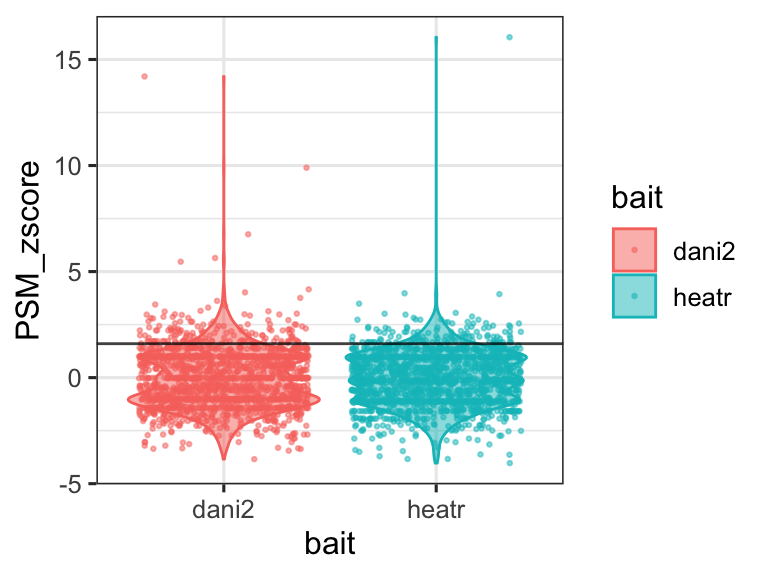

```r
ggplot(combined_frog, aes(x = bait, y = PSM_zscore, fill = bait, color = bait)) +
  geom_violin(alpha = 0.5) +
  geom_jitter(size = 0.5, alpha = 0.5) +   # overlay data points on distribution
  geom_hline(yintercept = 1.6, alpha = 0.75)    # add lines at z-value cutoffs
```

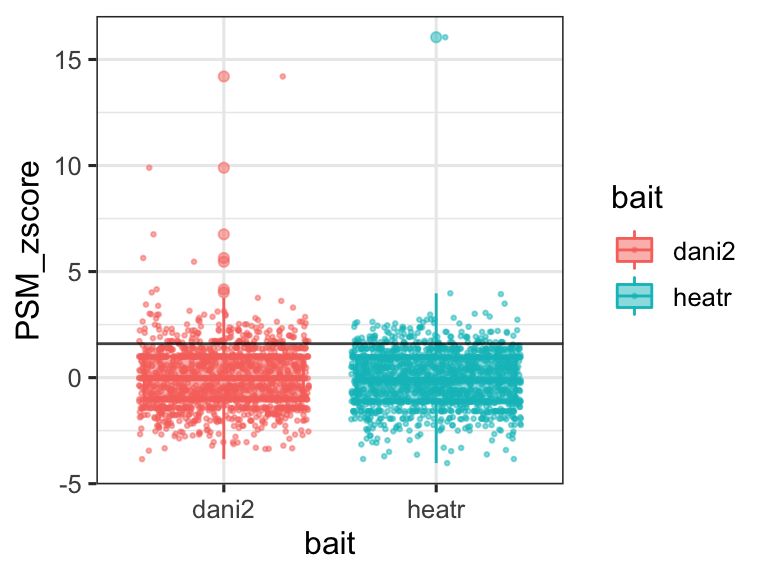

```r
ggplot(combined_frog, aes(x = bait, y = PSM_zscore, fill = bait, color = bait)) +
  geom_boxplot(alpha = 0.5) +
  geom_jitter(size = 0.5, alpha = 0.5) +   # overlay data points on distribution
  geom_hline(yintercept = 1.6, alpha = 0.75)    # add lines at z-value cutoffs
```

### 1.3 Joining an experiment table with an annotation table

Now we have a data frame that contains protein interaction data for both dnai2 and heatr2, but the actual identifiers in the `ID` are not informative. To investigate the interacting biology, we need to join an annotation table to the APMS data frame.

```r
# import the frog gene annotations
frog_annotations <- read_csv("frog_enog_annotations.csv")
head(frog_annotations)
```

```
## # A tibble: 6 × 6
##   ID          OG_category XENLA_GeneNames                HUMAN…¹ OG_an…² OG_ca…³
##   <chr>       <chr>       <chr>                          <chr>   <chr>   <chr>
## 1 ENOG411CP4H S           rhpn1.L, rhpn2.L, rhpn2.S      RHPN2P… Rhophi… Functi…
## 2 ENOG411CP4I S           arl14epl.L, arl14epl.S         ARL14E… ADP-ri… Functi…
## 3 ENOG411CP4J Z           myh1-2-1.S, myh1-2-1.L, Xelae… MYH3, … myosin… Cytosk…
## 4 ENOG411CP4K S           loc101733025.L, loc101732256-… SHISAL1 kiaa16… Functi…
## 5 ENOG411CP4M T           epha3.L, epha4.S, Xelaev18005… EPHA5,… Eph re… Signal…
## 6 ENOG411CP4N O           txndc11.L                      TXNDC11 thiore… Post-t…
## # … with abbreviated variable names ¹HUMAN_GeneNames, ²OG_annotation,
## #   ³OG_category_annotation
```

Note that the annotation data frame has an `ID` column that matches the `ID` column in the APMS data frame. Also notice that the annotation data frame has 14292 rows, and our APMS data frame has 3356 rows. The `left_join()` function keeps all the rows from the data frame used as the “left” input, while joining in places that match the common column (`ID` in this case) to the right data frame. Use `left_join()` to combine the APMS data frame with the annotation data frame, such that the final data frame has 3356 rows and 12 columns.

```r
combined_frog %>%
  left_join(frog_annotations, by = c("ID"="ID")) -> annoted_fg_data

nrow(annoted_fg_data)
```

```
## [1] 3356
```

```r
head(annoted_fg_data)
```

```
## # A tibble: 6 × 12
##   ID        ctrl_…¹ exp_P…² PSM_fc PSM_l…³ PSM_z…⁴ bait  OG_ca…⁵ XENLA…⁶ HUMAN…⁷
##   <chr>       <dbl>   <dbl>  <dbl>   <dbl>   <dbl> <chr> <chr>   <chr>   <chr>
## 1 ENOG411C…       0     274 241.      7.91   16.0  heatr S       dnaaf5… DNAAF5
## 2 ENOG411C…      31      79   2.19    1.13    3.98 heatr J       gcn1.S… GCN1
## 3 ENOG411C…      17      54   2.68    1.42    3.94 heatr U       ipo7.L  IPO7, …
## 4 ENOG411C…      17      49   2.43    1.28    3.49 heatr U       ipo9.L… IPO9
## 5 ENOG411C…       0      10   9.64    3.27    3.05 heatr Z       myo5b.… MYO5A,…
## 6 ENOG411C…       5      22   3.36    1.75    3.01 heatr O       hsph1.… HSPA4,…
## # … with 2 more variables: OG_annotation <chr>, OG_category_annotation <chr>,
## #   and abbreviated variable names ¹ctrl_PSMs, ²exp_PSMs, ³PSM_log2fc,
## #   ⁴PSM_zscore, ⁵OG_category, ⁶XENLA_GeneNames, ⁷HUMAN_GeneNames
```

Now each observation is connected to a *X. laevis* gene name, in addition to the gene’s human cousin. Not all genes have annotations, even though *X. laevis* is considered a model organism. This is common in bioinformatics.

**Bonus challenge:** Plot a bar chart with `OG_category_annotation` on the x-axis. Color by bait. Flip the chart so long descriptions are more readable using the `coord_flip()` layer. Try `facet_wrap()`, does this improve clarity? Remove the y-axis label.

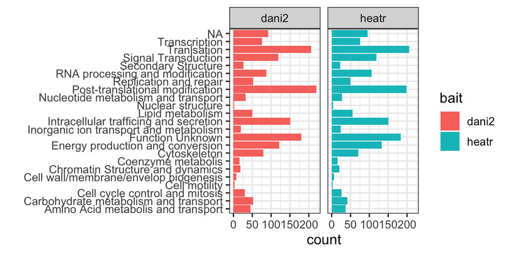

```r
ggplot(annoted_fg_data, aes(x = OG_category_annotation, fill = bait)) +
  geom_bar() +
  xlab("") + # remove X label
  coord_flip() +
  facet_wrap(~bait)
```

## 2. Subsetting data (`filter()`, `select()`)

In biological data analysis, we’re often most interested in a specific subset of data–usually scores above some threshold (p-values, z-scores, fold changes in gene expression) or the behavior of a specific gene/protein family relative to time or different conditions..

Perform the following operations to pare down the combined APMS data frame. Use the pipe (%>%) to chain data operations together and save the results to a new data frame in a single step:

1. Filter the combined and annotated APMS data frame (generated in the previous step) to only contain observations with `PSM_zscore` > 1.6 (p ~ 0.05) to pull out proteins significantly interacting with dnai2 and heatr2 (use the `filter()` function).
2. Then, in the same line of code, pipe (`%>%`) into `select()` to extract only the columns named `ID`, `bait`, `PSM_log2fc`, `PSM_zscore`, `OG_category_annotation`.
3. Finally, again in the same line of code, pipe (`%>%`) into `arrange()` to re-sort the data frame to descend by `PSM_zscore` (i.e., highest z-scores should be at the top).

```r
filtered_df <- annoted_fg_data %>%
  filter(PSM_zscore > 1.6) %>%
  select(ID, bait, PSM_log2fc, PSM_zscore, OG_category_annotation) %>%
  arrange(desc(PSM_zscore))

head(filtered_df)
```

```
## # A tibble: 6 × 5
##   ID          bait  PSM_log2fc PSM_zscore OG_category_annotation
##   <chr>       <chr>      <dbl>      <dbl> <chr>
## 1 ENOG411CUGY heatr       7.91      16.0  Function Unknown
## 2 ENOG411DGHA dani2       7.64      14.2  Cytoskeleton
## 3 ENOG411CW1E dani2       1.69       9.90 Lipid metabolism
## 4 ENOG411DGH7 dani2       5.53       6.76 Cytoskeleton
## 5 ENOG411CT94 dani2       4.15       5.64 Cytoskeleton
## 6 ENOG411CQ77 dani2       2.38       5.47 Nucleotide metabolism and transport
```

Plot another bar plot, the same way we made the plot in Section 1.3; compare the distribution of functional categories for the most significant proteins versus the unfiltered data set depicted in Section 1.3. **Bonus challenge:** Reorder the bar plots so that the functional categories with the highest counts are grouped together using `fct_infreq()`.

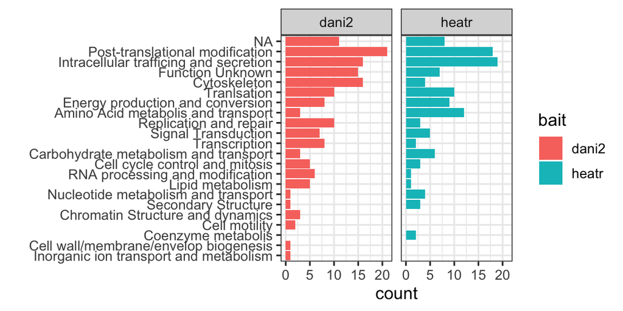

```r
## fct_rev() is not a command we covered directly in class

ggplot(filtered_df, aes(x = fct_rev(fct_infreq(OG_category_annotation)),
                        fill = bait)) +
  geom_bar() +
  xlab("") +
  coord_flip() +
  facet_wrap(~bait)
```